# Stork ne(s)t

```r
library(fs)
library(tidyverse)
library(lubridate)
library(hms)
library(here)
```

# Select samples for labeling

The goal is to randomly select 200 sample images for manual labeling which are then used to create a deep neural network which classifies if a stork is present or not.  
The ratio of stork present/absent should be around 50:50. If we’re far of this, we need to sample more at a later timepoint.

*Note: Now is that later timepoint and it was decided to sample and label 400 samples instead.*

## Read filenames from downloaded images (2019 only)

```r
# For some reason list all files from R directly resulted in a weird bug. It was therefore
# decided to do this part using a shell script instead.

files_2019 <-
  # read the list of files from 2019 which was created using the shell script "image-list.sh"
  read_csv(here("images", "2019", "files_2019.csv"), col_names = "filename") %>%
  filter(filename != "files_2019.csv") %>%
  # remove .jpg extension
  mutate(datetime = str_sub(filename, end = -5)) %>%
  # split into date and time and format properly
  separate(datetime, into = c("date", "time"), sep = "_") %>%
  mutate(date = ymd(date),
         time = as_hms(paste0(str_replace(time, "-", ":"), ":00")))
```

There are 69894 images downloaded which range from 2019-01-01 to 2019-08-31.

## Distribution of images over time

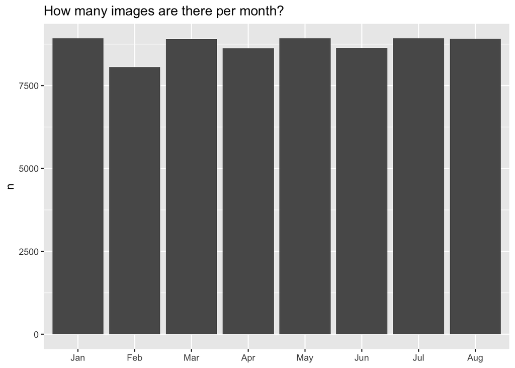

```r
files_2019 %>%
  mutate(month = month(date, label = TRUE)) %>%
  count(month) %>%
  ggplot(aes(x = month, y = n)) +
  geom_bar(stat = "identity") +
  labs(x = NULL,
       title = "How many images are there per month?")
```

It looks like there are no big gaps in time where there are missing images.

```r
all_days <-
  seq(from = c(ISOdate(2019,1,1)), to = c(ISOdate(2019,8,31)), by = "day") %>%
  as.Date()

all_timepoints <-
  crossing(date = all_days,
           h = seq(from = 0, to = 23),
           m = seq(from = 0, to = 55, by = 5),
           s = 0) %>%
  transmute(date = date,
            time = as_hms(paste0(h, ":", m, ":", s))) %>%
  # remove entries from 2019-03-31_02-00 until 2019-03-31_02-55
  # which are missing due to daylight-saving time.
  filter(!(date == "2019-03-31" & hour(time) == 2))

missing_timepoints <-
  anti_join(all_timepoints, files_2019, by = c("date", "time"))
```

We can check exactly which ones are missing. During that time period of 69972 possible timepoints (image each 5min) only 78 are missing.

## Sampling images for labeling

For the first round of sampling and labeling, only colored images were chosen. Therefore images captured between 9am and 4pm were filtered before randomly selecting 400 of those.

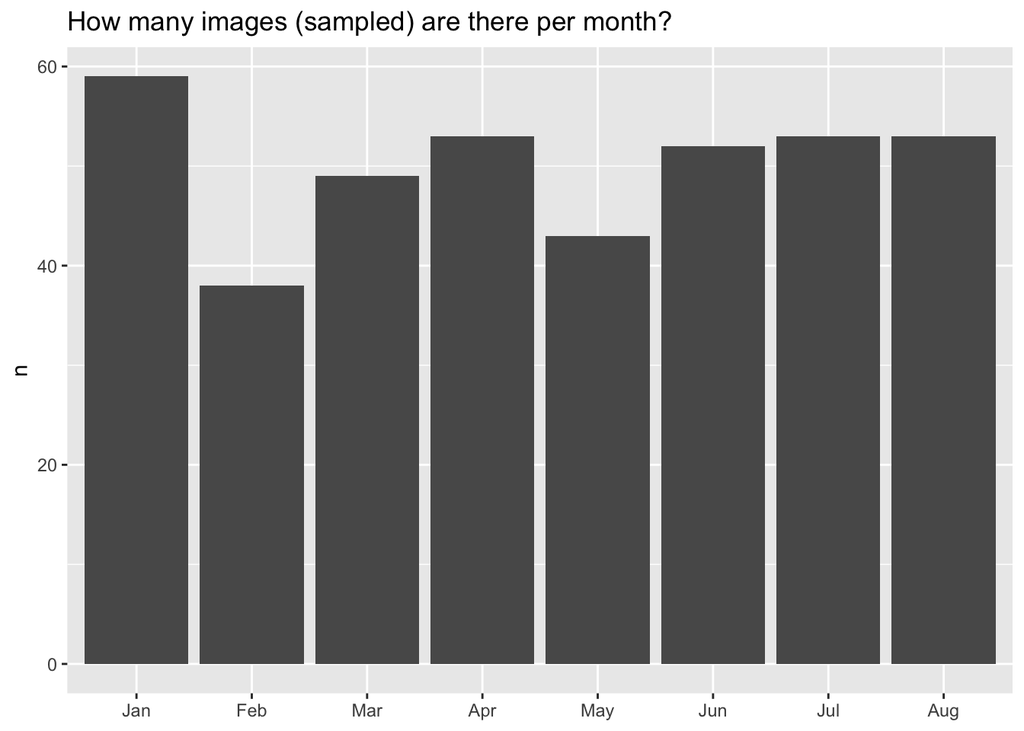

```r
# Very important to set a seed in order to reproduce the sampling
set.seed(20200421)

files_2019_sampled <-
  files_2019 %>%
  filter(time >= as_hms("09:00:00"),
         time <= as_hms("16:00:00")) %>%
  sample_n(400) %>%
  arrange(filename)

invisible(file.copy(from = here("images", "2019", files_2019_sampled$filename),
                    to = here("images", "2019_sampled", files_2019_sampled$filename)))

write_csv(files_2019_sampled, path = here("images", "2019_sampled", "files_2019_sampled.csv"))

files_2019_sampled %>%
  mutate(month = month(date, label = TRUE)) %>%
  count(month) %>%
  ggplot(aes(x = month, y = n)) +
  geom_bar(stat = "identity") +
  labs(x = NULL,
       title = "How many images (sampled) are there per month?")
```